# Mother to Child HIV Transmission and its socioeconomic context

# **HIV Transmission vs Birth Rate**

The scatterplot of HIV transmission rates against birth rates reveals a positive correlation: Countries with higher birth rates often exhibit higher Mother-to-child HIV transmission rates. High birth rates, combined with limited maternal healthcare resources, can increase the risk of transmission. This suggests that family planning, maternal health programs, and healthcare education should be integral parts of HIV prevention strategies.

*Higher births + low healthcare = more HIV risk*

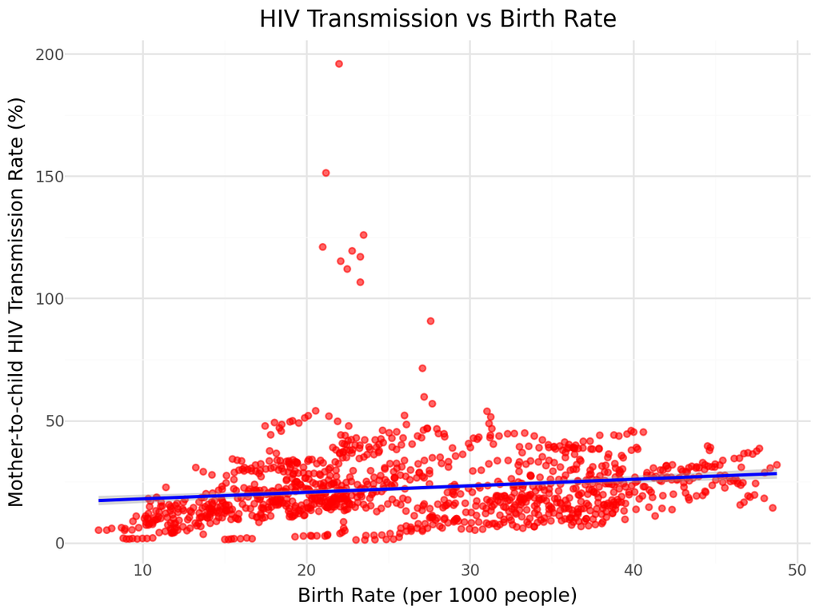

```python
#HIV vs Birth Rate
(ggplot(combined) +
 aes(x='Birth_Rate', y='HIV_Transmission') +
 geom_point(color='red', alpha=0.6) +
 stat_smooth(method='lm', color='blue') +
 labs(title='HIV Transmission vs Birth Rate',
      x='Birth Rate (per 1000 people)', y='Mother-to-child HIV Transmission Rate (%)') +
 theme_minimal())
```

# **Conclusion**

This report analyzed Mother-to-child HIV transmission rates across countries, drawing on key global health and socioeconomic indicators.

Time series analysis revealed encouraging global progress, with a gradual decline in transmission rates over recent years — a positive result of international efforts to improve maternal health services and expand access to antiretroviral therapies.

Overall, while notable progress has been made, the data underscores the urgent need for sustained, targeted interventions — especially in low-income and high birth rate regions — to further reduce and ultimately eliminate Mother-to-child HIV transmission worldwide.